# Zombies Homework in Module 8

Zeynep Senveli

10/1/2017

Reading in the Zombies.csv file:

```r
library(ggplot2)
library(curl)
f <- f <- curl("https://raw.githubusercontent.com/fuzzyatelin/fuzzyatelin.github.io/master/AN597_Fall17/zombies.csv")
d <- read.csv(f, header = TRUE, sep = ",", stringsAsFactors = FALSE)
head(d)
```

```
##   id first_name last_name gender   height   weight zombies_killed
## 1  1      Sarah    Little Female 62.88951 132.0872              2
## 2  2       Mark    Duncan   Male 67.80277 146.3753              5
## 3  3    Brandon     Perez   Male 72.12908 152.9370              1
## 4  4      Roger   Coleman   Male 66.78484 129.7418              5
## 5  5      Tammy    Powell Female 64.71832 132.4265              4
## 6  6    Anthony     Green   Male 71.24326 152.5246              1
##   years_of_education                           major      age
## 1                  1                medicine/nursing 17.64275
## 2                  3 criminal justice administration 22.58951
## 3                  1                       education 21.91276
## 4                  6                  energy studies 18.19058
## 5                  3                       logistics 21.10399
## 6                  4                  energy studies 21.48355
```

Calculating the population mean for different variables:

```r
mean.height <- mean(d$height)
mean.height
```

```
## [1] 67.6301
```

```r
mean.weight <- mean(d$weight)
mean.weight
```

```
## [1] 143.9075
```

```r
mean.zk <- mean(d$zombies_killed)
mean.zk
```

```
## [1] 2.992
```

```r
mean.edu <- mean(d$years_of_education)
mean.edu
```

```
## [1] 2.996
```

```r
mean.age <- mean(d$age)
mean.age
```

```
## [1] 20.04696
```

Since the embedded function uses the sample degrees of freedom (n-1), I need to write up a new function to calculate the standard deviation for the population:

```r
stadev <- function(x) {
standard.deviation <- sqrt(sum((x - mean(x))^2)/(length(d$id)))
return(standard.deviation)
}
```

Calculating the population standard deviation for the variables:

```r
stdev.height <- stadev(d$height)
stdev.height
```

```
## [1] 4.30797
```

```r
stdev.weight <- stadev(d$weight)
stdev.weight
```

```
## [1] 18.39186
```

```r
stdev.zk <- stadev(d$zombies_killed)
stdev.zk
```

```
## [1] 1.747551
```

```r
stdev.edu <- stadev(d$years_of_education)
stdev.edu
```

```
## [1] 1.675704
```

```r
stdev.age <- stadev(d$age)
stdev.age
```

```
## [1] 2.963583
```

Plotting the variables by gender using ggplot2:

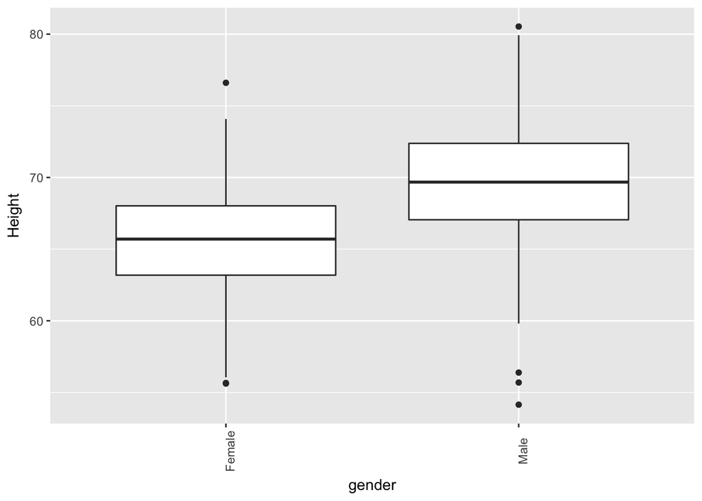

```r
library(ggplot2)
height.boxplot <- ggplot(data = d, aes(x = gender, y = height))
height.boxplot <- height.boxplot + geom_boxplot()
height.boxplot <- height.boxplot + theme(axis.text.x = element_text(angle = 90))
height.boxplot <- height.boxplot + ylab("Height")
height.boxplot
```

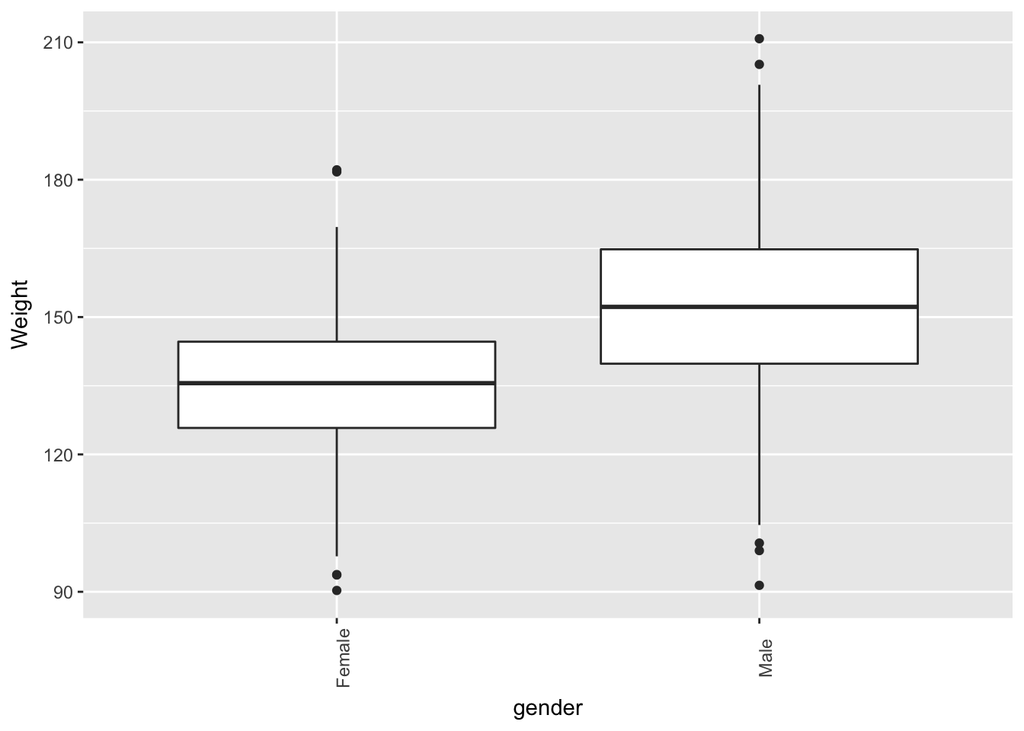

```r
weight.boxplot <- ggplot(data = d, aes(x = gender, y = weight))
weight.boxplot <- weight.boxplot + geom_boxplot()
weight.boxplot <- weight.boxplot + theme(axis.text.x = element_text(angle = 90))
weight.boxplot <- weight.boxplot + ylab("Weight")
weight.boxplot
```

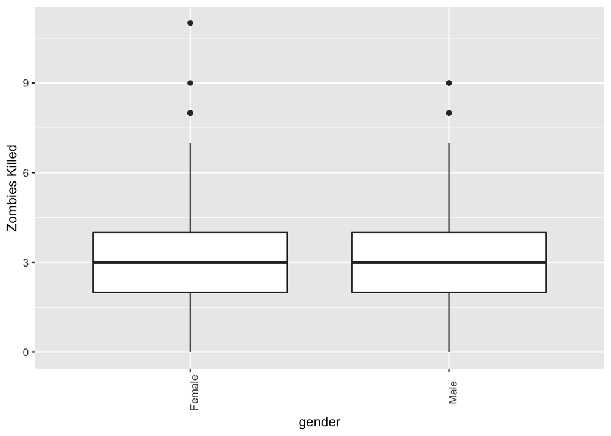

```r
zk.boxplot <- ggplot(data = d, aes(x = gender, y = zombies_killed))
zk.boxplot <- zk.boxplot + geom_boxplot()
zk.boxplot <- zk.boxplot + theme(axis.text.x = element_text(angle = 90))
zk.boxplot <- zk.boxplot + ylab("Zombies Killed")
zk.boxplot
```

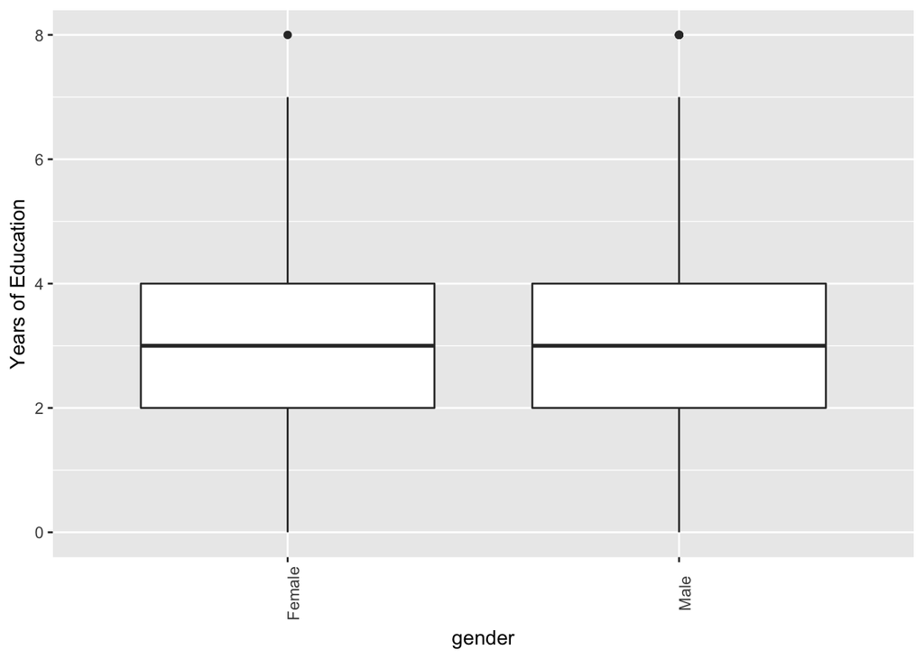

```r
edu.boxplot <- ggplot(data = d, aes(x = gender, y = years_of_education))
edu.boxplot <- edu.boxplot + geom_boxplot()
edu.boxplot <- edu.boxplot + theme(axis.text.x = element_text(angle = 90))
edu.boxplot <- edu.boxplot + ylab("Years of Education")
edu.boxplot
```

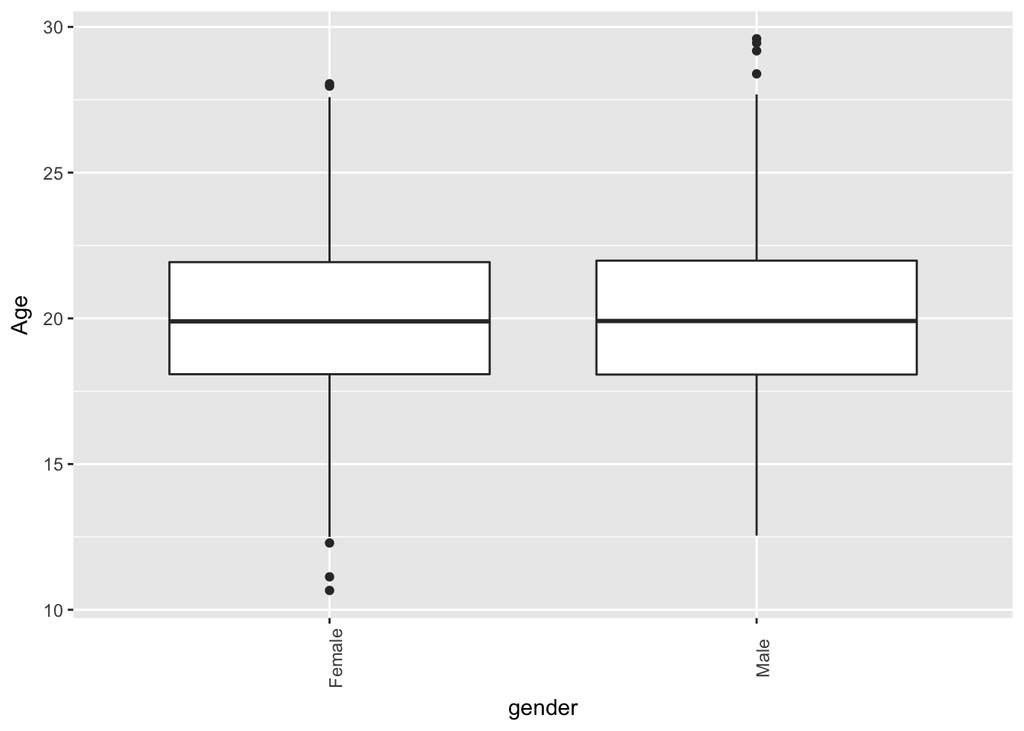

```r
age.boxplot <- ggplot(data = d, aes(x = gender, y = age))
age.boxplot <- age.boxplot + geom_boxplot()
age.boxplot <- age.boxplot + theme(axis.text.x = element_text(angle = 90))
age.boxplot <- age.boxplot + ylab("Age")
age.boxplot
```

Making scatter plots for height and weight by age:

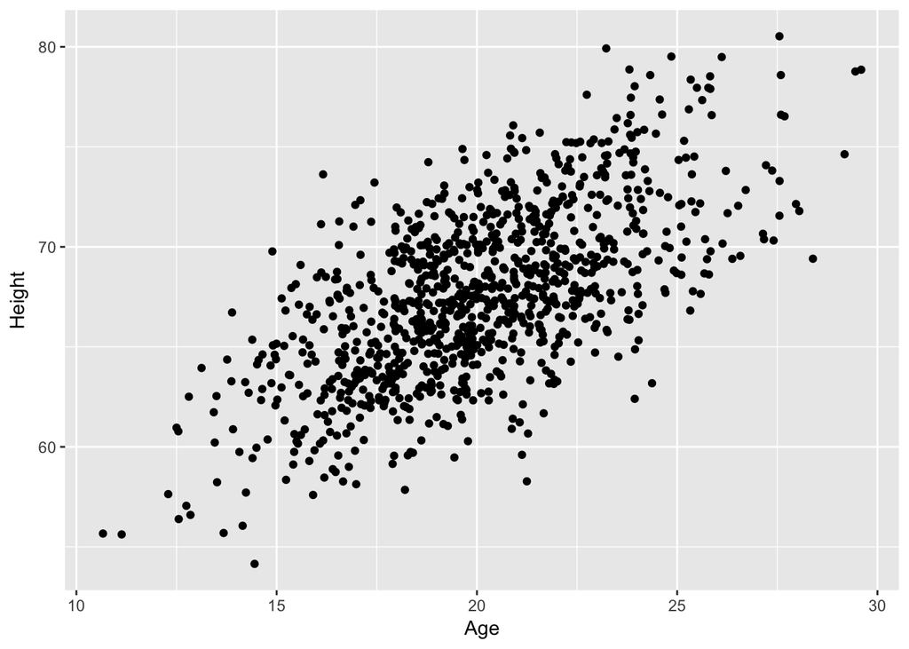

```r
height.scplot <- ggplot(data = d, aes(x = age, y = height))
height.scplot <- height.scplot + xlab("Age") + ylab("Height")
height.scplot <- height.scplot + geom_point()
height.scplot <- height.scplot + theme(legend.position = "bottom", legend.title = element_blank())
height.scplot
```

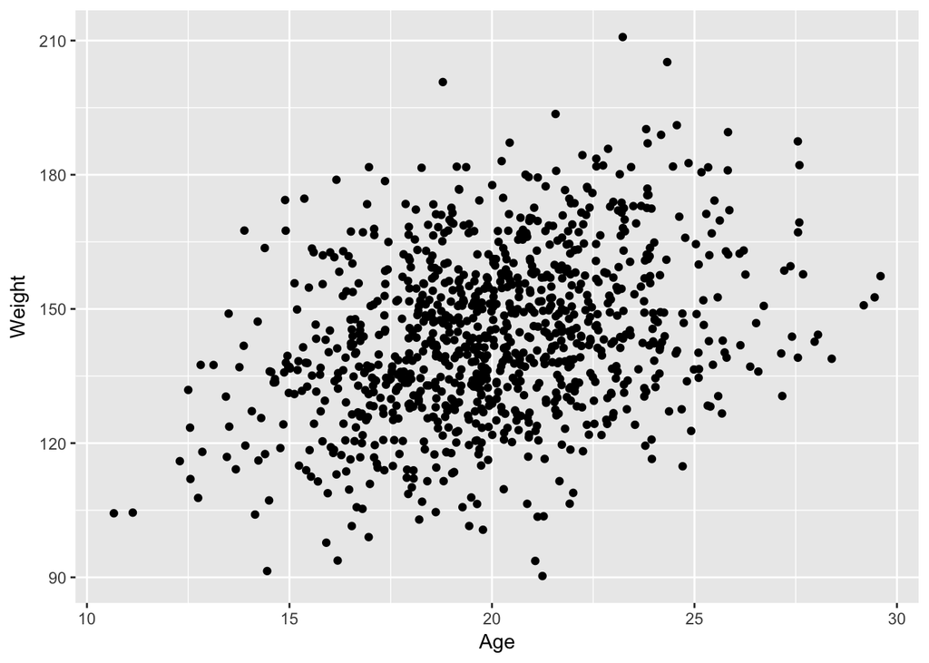

```r
weight.scplot <- ggplot(data = d, aes(x = age, y = weight))
weight.scplot <- weight.scplot + xlab("Age") + ylab("Weight")
weight.scplot <- weight.scplot + geom_point()
weight.scplot <- weight.scplot + theme(legend.position = "bottom", legend.title = element_blank())
weight.scplot
```

Plotting histograms to see if the quantitative variables have been drawn from a normally distributed population:

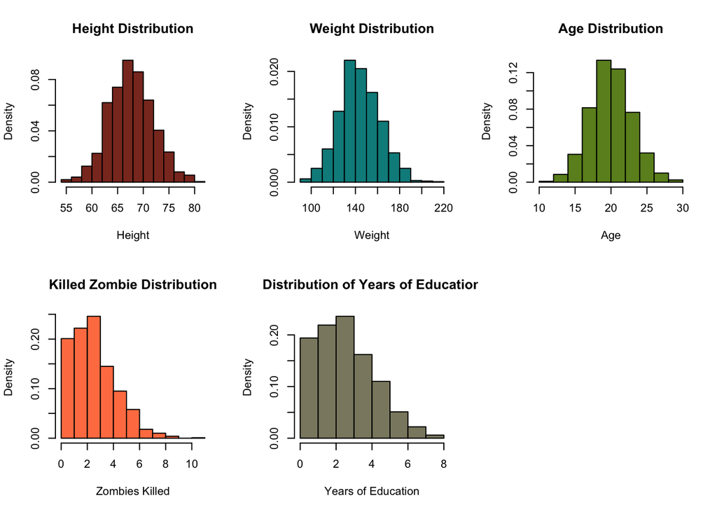

```r
par(mfrow = c(2, 3))
attach(d)
hist(height, freq = FALSE, col = "tomato4", main = "Height Distribution", xlab = "Height",
    ylab = "Density")
hist(weight, freq = FALSE, col = "cyan4", main = "Weight Distribution", xlab = "Weight",
    ylab = "Density")
hist(age, freq = FALSE, col = "olivedrab", main = "Age Distribution", xlab = "Age",
    ylab = "Density")
hist(zombies_killed, freq = FALSE, col = "coral", main = "Killed Zombie Distribution", xlab = "Zombies Killed",     ylab = "Density")
hist(years_of_education, freq = FALSE, col = "lemonchiffon4", main = "Distribution of Years of Education", xlab =       "Years of Education", ylab = "Density")
detach(d)
```

According to the histograms, height, weight, and age seem to be drawn from normally distributions when zombies killed and years of education are skewed to the right (positively skewed) so possibly a Poisson distribution.

Sampling (once) a set of 30 survivors and calculating the sample’s mean and standard deviation:

```r
s <- d[sample(nrow(d), 30), ]
s
```

```
##      id first_name  last_name gender   height    weight zombies_killed
## 46   46      Maria     Hudson Female 65.80217 139.41537              2
## 649 649    Charles   Mcdonald   Male 65.34881 146.84062              6
## 812 812      Brian Cunningham   Male 70.64534 142.91934              8
## 805 805     Martha    Coleman Female 61.67773 111.50505              5
## 542 542        Roy     Greene   Male 71.72426 165.53502              0
## 541 541      Roger       Gray   Male 63.17451 157.18907              1
## 127 127       Judy     Fields Female 62.82903 127.73019              5
## 433 433      Ralph    Stanley   Male 72.33186 167.90658              3
## 647 647      Wanda     Rogers Female 72.07851 148.85490              3
## 87   87     Martin    Russell   Male 74.37837 171.01940              6
## 950 950  Christina      Evans Female 67.29623 147.18906              1
## 378 378       Jean    Johnson Female 67.67221 136.64281              5
## 462 462       Lois     Garcia Female 59.00067 105.30837              3
## 235 235      Betty     Howard Female 63.54701 145.41724              4
```

[output cut: 47 more lines]

Means of the quantitative variables in my sample s of size 30:

```r
mean.s.height <- mean(s$height)
mean.s.height
```

```
## [1] 67.35529
```

```r
mean.s.weight <- mean(s$weight)
mean.s.weight
```

```
## [1] 144.3697
```

```r
mean.s.age <- mean(s$age)
mean.s.age
```

```
## [1] 19.98334
```

```r
mean.s.zk <- mean(s$zombies_killed)
mean.s.zk
```

```
## [1] 3.166667
```

```r
mean.s.edu <- mean(s$years_of_education)
mean.s.edu
```

```
## [1] 3.5
```

Standard deviations of the quantitative variables in my sample s of size 30:

```r
sd.s.height <- sd(s$height)
sd.s.height
```

```
## [1] 4.685103
```

```r
sd.s.weight <- sd(s$weight)
sd.s.weight
```

```
## [1] 21.09178
```

```r
sd.s.age <- sd(s$age)
sd.s.age
```

```
## [1] 2.698621
```

```r
sd.s.zk <- sd(s$zombies_killed)
sd.s.zk
```

```
## [1] 2.035603
```

```r
sd.s.edu <- sd(s$years_of_education)
sd.s.edu
```

```
## [1] 1.696853
```

Calculating the standard error of the sample s:

```r
se.s.height <- sd.s.height/sqrt(30)
se.s.height
```

```
## [1] 0.8553788
```

```r
se.s.weight <- sd.s.weight/sqrt(30)
se.s.weight
```

```
## [1] 3.850814
```

```r
se.s.age <- sd.s.age/sqrt(30)
se.s.age
```

```
## [1] 0.4926986
```

```r
se.s.zk <- sd.s.zk/sqrt(30)
se.s.zk
```

```
## [1] 0.3716485
```

```r
se.s.edu <- sd.s.edu/sqrt(30)
se.s.edu
```

```
## [1] 0.3098016
```

Building confidence intervals of 95% for the quantitative variables for the sample s:

```r
lower.CI.s.height <- mean(s$height)-(qt(p=0.975,df=29)*se.s.height)
upper.CI.s.height <- mean(s$height)+(qt(p=0.975,df=29)*se.s.height)
CI.s.height <- c(lower.CI.s.height, upper.CI.s.height)
CI.s.height
```

```
## [1] 65.60585 69.10474
```

```r
lower.CI.s.weight <- mean(s$weight)-(qt(p=0.975,df=29)*se.s.weight)
upper.CI.s.weight <- mean(s$weight)+(qt(p=0.975,df=29)*se.s.weight)
CI.s.weight <- c(lower.CI.s.weight, upper.CI.s.weight)
CI.s.weight
```

```
## [1] 136.4939 152.2455
```

```r
lower.CI.s.age <- mean(s$age)-(qt(p=0.975,df=29)*se.s.age)
upper.CI.s.age <- mean(s$height)+(qt(p=0.975,df=29)*se.s.age)
CI.s.age <- c(lower.CI.s.age, upper.CI.s.age)
CI.s.age
```

```
## [1] 18.97566 68.36298
```

```r
lower.CI.s.zk <- mean(s$zombies_killed)-(qpois(p=0.975,lambda=mean(s$zombies_killed))*se.s.zk)
upper.CI.s.zk <- mean(s$zombies_killed)+(qpois(p=0.975,lambda=mean(s$zombies_killed))*se.s.zk)
CI.s.zk <- c(lower.CI.s.zk, upper.CI.s.zk)
CI.s.zk #Confidence Inteval - Sample - Zombies killed
```

```
## [1] 0.5651272 5.7682061
```

```r
lower.CI.s.edu <- mean(s$years_of_education)-(qpois(p=0.975,lambda=mean(s$years_of_education))*se.s.edu)
upper.CI.s.edu <- mean(s$years_of_education)+(qpois(p=0.975,lambda=mean(s$years_of_education))*se.s.edu)
CI.s.edu <- c(lower.CI.s.edu, upper.CI.s.edu)
CI.s.edu #Confidence Inteval - Sample - Years of Education
```

```
## [1] 1.021587 5.978413
```

# height and mean

```r
k <- 99
ht <- NULL
for (i in 1:k) {
    ht[[i]] <- sample(s$height)
}
head(ht)
```

```
## [[1]]
##  [1] 74.34413 65.12383 70.18705 63.84095 62.82903 72.10447 67.29623
##  [8] 67.67221 66.63676 71.72426 72.33186 65.80217 67.09539 72.07851
## [15] 62.06469 72.09908 63.54701 63.50868 75.30248 61.67773 63.17451
## [22] 59.00067 74.21998 74.37837 67.35961 63.06785 70.64534 65.34881
## [29] 59.80658 66.39057
##
## [[2]]
##  [1] 74.21998 72.10447 61.67773 65.12383 67.09539 72.07851 74.34413
##  [8] 67.67221 59.00067 62.06469 66.63676 63.50868 70.18705 66.39057
## [15] 63.54701 72.09908 63.17451 70.64534 63.06785 74.37837 59.80658
## [22] 67.29623 75.30248 65.34881 67.35961 63.84095 62.82903 71.72426
## [29] 72.33186 65.80217
##
## [[3]]
```

[output cut: 26 more lines]

```r
mh <- NULL
for (i in 1:k) {
    mh[i] <- mean(ht[[i]])
}
mean(mh)
```

```
## [1] 67.35529
```

# weight and mean

```r
k <- 99
wt <- NULL
for (i in 1:k) {
    wt[[i]] <- sample(s$weight)
}
head(wt)
```

```
## [[1]]
##  [1] 171.01940 132.35222 164.48874 164.39177 133.38346 145.41724 139.41537
##  [8] 167.90658 142.91934 180.56301 137.00266 148.85490 105.30837 136.64281
## [15] 114.54661  98.99585 157.35376 146.78311 147.18906 157.18907 137.50644
## [22] 146.84062 168.92029 181.70385 130.93967 130.01734 165.53502 138.66806
## [29] 111.50505 127.73019
##
## [[2]]
##  [1] 105.30837 114.54661 181.70385 130.01734 148.85490 138.66806  98.99585
##  [8] 132.35222 137.00266 157.18907 146.78311 164.48874 111.50505 139.41537
## [15] 147.18906 171.01940 167.90658 157.35376 127.73019 180.56301 142.91934
## [22] 130.93967 133.38346 164.39177 137.50644 145.41724 168.92029 146.84062
## [29] 165.53502 136.64281
##
## [[3]]
```

[output cut: 26 more lines]

```r
mw <- NULL
for (i in 1:k) {
    mw[i] <- mean(wt[[i]])
}
mean(mw)
```

```
## [1] 144.3697
```

# age and mean

```r
k <- 99
at <- NULL
for (i in 1:k) {
    at[[i]] <- sample(s$age)
}
head(at)
```

```
## [[1]]
##  [1] 25.17245 17.09044 16.95601 18.79596 22.32466 21.84500 16.96297
##  [8] 18.84754 18.09670 17.79204 21.66693 19.73793 18.62649 21.71185
## [15] 20.35543 18.62427 23.90511 21.92487 22.96536 19.53898 25.03579
## [22] 25.05183 18.61992 16.53939 17.19527 19.73432 17.01380 18.31203
## [29] 22.25385 16.80293
##
## [[2]]
##  [1] 19.53898 19.73793 16.80293 22.96536 18.09670 16.95601 17.19527
##  [8] 17.79204 25.17245 18.62649 16.96297 18.31203 22.25385 21.84500
## [15] 20.35543 16.53939 17.09044 19.73432 21.71185 21.92487 18.84754
## [22] 18.79596 23.90511 25.05183 25.03579 18.61992 21.66693 22.32466
## [29] 18.62427 17.01380
##
## [[3]]
```

[output cut: 26 more lines]

```r
ma <- NULL
for (i in 1:k) {
    ma[i] <- mean(at[[i]])
}
mean(ma)
```

```
## [1] 19.98334
```

# zombies killed and mean

```r
k <- 99
zt <- NULL
for (i in 1:k) {
    zt[[i]] <- sample(s$zombies_killed)
}
head(zt)
```

```
## [[1]]
##  [1] 1 1 1 6 6 2 3 3 2 3 1 1 4 5 5 2 5 2 6 3 0 3 0 2 3 8 3 6 5 3
##
## [[2]]
##  [1] 1 2 3 3 5 6 1 0 6 4 3 6 0 6 2 2 8 1 1 5 3 5 3 2 2 3 1 3 3 5
##
## [[3]]
##  [1] 3 1 2 3 1 4 5 3 3 2 1 5 3 5 0 1 2 3 8 0 1 2 6 6 3 2 3 5 6 6
##
## [[4]]
##  [1] 3 6 3 3 5 5 5 5 6 1 6 2 2 1 1 1 0 8 3 3 2 0 1 4 3 2 3 6 2 3
##
## [[5]]
##  [1] 5 5 6 2 3 4 3 3 3 0 2 6 6 1 1 8 1 3 1 1 2 3 5 3 2 5 0 2 6 3
##
## [[6]]
##  [1] 6 1 5 1 2 3 2 8 1 4 6 2 6 3 3 6 3 3 5 1 2 2 5 0 3 3 1 0 3 5
```

```r
mz <- NULL
for (i in 1:k) {
    mz[i] <- mean(zt[[i]])
}
mean(mz)
```

```
## [1] 3.166667
```

# years of education and mean

```r
k <- 99
et <- NULL
for (i in 1:k) {
    et[[i]] <- sample(s$years_of_education)
}
head(et)
```

```
## [[1]]
##  [1] 3 0 4 7 4 2 4 5 6 3 4 4 4 4 3 4 4 3 3 1 2 4 2 5 1 2 4 2 3 8
##
## [[2]]
##  [1] 3 4 2 6 1 4 4 4 2 7 1 3 3 2 2 2 4 8 4 4 5 4 4 4 4 0 3 3 5 3
##
## [[3]]
##  [1] 2 1 8 4 4 4 4 5 2 4 3 4 3 2 1 2 3 5 4 3 4 6 4 0 3 7 4 3 2 4
##
## [[4]]
##  [1] 3 7 4 2 4 4 3 4 3 2 4 4 4 4 3 2 8 4 0 2 1 6 3 5 4 3 5 1 4 2
##
## [[5]]
##  [1] 6 0 2 1 3 4 4 3 3 2 4 1 8 3 2 4 5 5 4 4 4 2 2 4 4 4 3 7 3 4
##
## [[6]]
##  [1] 2 1 3 2 5 1 2 4 4 2 3 4 4 3 2 4 4 3 6 8 5 4 4 7 0 4 3 3 4 4
```

```r
me <- NULL
for (i in 1:k) {
    me[i] <- mean(et[[i]])
}
mean(me)
```

```
## [1] 3.5
```